# Tutorial on the evaluation of vaccines with administrative data data

A companion to the WHO reference guide

##Getting started Before starting, you should install R and Rstudio on your computer. R can be downloaded from here: https://cran.r-project.org/mirrors.html. and RStudio can be downloaded from https://rstudio.com/products/rstudio/. Both are free. Once both programs are installed, open RStudio, and either open the .Rmd file practical exercises.Rmd or create a new RMarkdown document File/New File/R Notebook.

Load the libraries we need for this exercise. The first time you do this, run the code that is commented off with the install.packages function. You should only have to do this once.

```r
#install.packages(c('lubridate', 'RCurl','devtools','xtable','knitr','htmlTable','coda','rmdformats','httr'))
#library(devtools)
#devtools::install_github('https://github.com/weinbergerlab/InterventionEvaluatR')
library(lubridate)
library(RCurl)
library(knitr)
library(htmlTable)
library(InterventionEvaluatR)
library(coda)
library(rmdformats)
library(httr)
library(xtable)
```

## Introduction to the tutorial

In this tutorial, you will learn about: 1. The types of administrative data 2. The minimum requirement of the data for performing a credible analysis 3. How to extract relevant information from these databases 4. How to format the data into time series 5. How to perform visual quality checks 6. How to fit models to the data to evaluate vaccine impact 7. How to interpret and describe the results

This tutorial is designed for individuals without extensive experience in R, but if you want to learn about the R software, which underlies these anayses, you can learn some basics in this other tutorial: https://weinbergerlab.shinyapps.io/SurveillanceIntroR/. In this tutorial, we will format and analyze publicly-available data from Ecuador. these data for 2001-2015 were downloaded from the Instituto Nacional de Estadisticas y Censos https://www.ecuadorencifras.gob.ec/defunciones-generales-y-fetales-bases-de-datos/

The key variables we will work with are: -Cause: The main cause of death (‘causa basica’), with the first 3-digits of the ICD10 code -date: formatted as YYYY-MM-01 -age.years age in years

This dataset has all deaths for children <59 months of age.

PCV7 in Aug-2010 PCV10 (2+1) in Feb-2011 PCV10 (3+0) in Feb-2014

The data are stored as an R dataset.

## Read in and explore data

```r
githubURL <- ("https://raw.githubusercontent.com/DanWeinberger/who-guidance-materials/master/Practical%20exercises/ecuador%20raw/u5.deaths.2001.2015.rds")
download.file(githubURL,"ecuador_raw.rds", method="curl") #downloads file to working directory
d1 <- readRDS("ecuador_raw.rds") #imports file into R and saves as object 'd1'
```

### Look at the first few lines

```r
head(d1)
```

```
##          date  age.years cause
## 17 2001-01-01 0.58630137   Q89
## 26 2001-01-01 1.08767123   A09
## 37 2001-01-01 0.08493151   P23
## 61 2001-01-01 0.58630137   J18
## 71 2001-01-01 0.58630137   J96
## 80 2001-02-01 0.25205479   J18
```

Make sure R knows that the ‘date’ variable is a date. We tell it tha the date has a 4 digit year (%Y), a 2 digit month (%m), and 2 digit day (%d), separated by dashes.

```r
d1$date<-as.Date(d1$date,"%Y-%m-%d")
```

Let’s also make sure that cause is stored as a character variable

```r
d1$cause<-as.character(d1$cause)
```

### Basic explorations. What is the distibution of ages? of Dates? (make a histogram for each)

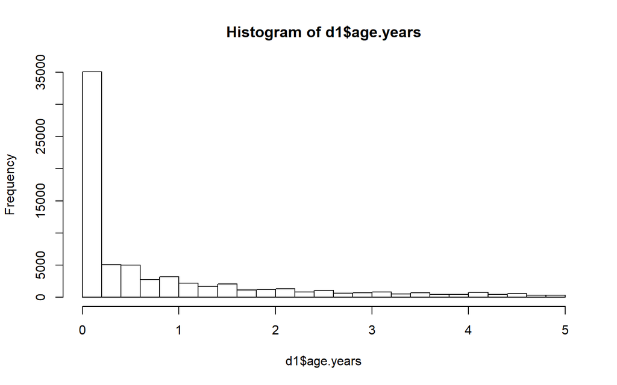

```r
hist(d1$age.years)
```

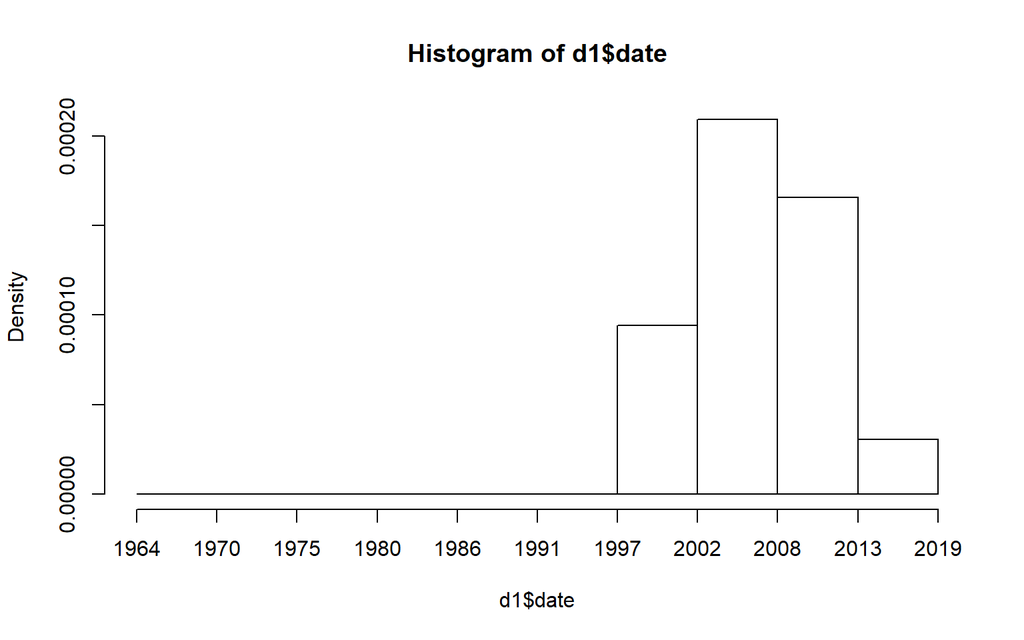

```r
hist(d1$date, breaks=10)
```

This shows there are some erroneous dates. There shouldn’t be any here before Jan 2001. Filter it here

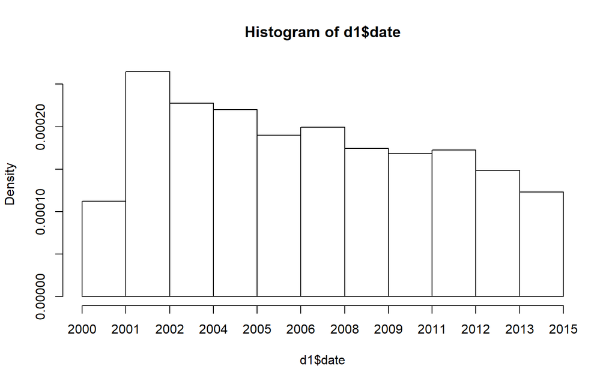

```r
d1<-d1[d1$date>=as.Date('2001-01-01'),]
hist(d1$date, breaks=10)
```

### Which codes are the most commonly used in this database?

Make a table of the 50 most common codes

```
##
##  J18  P07  P36  P22  A09  Q24  P23  R07  R99  P20  P24  R50  Q89  E43  J20
## 6844 6650 3035 2605 2516 2137 1501 1455 1388 1355 1339 1338 1238 1188 1125
##  P28  A41  R09  P21  W74  V09  X59  R63  R05  J96  A04  Q03  P29  P39  V89
## 1115 1028  851  827  713  695  625  603  578  557  530  527  503  498  482
##  P77  Q21  W84  E46  G80  Q90  I46  I50  Q79  R95  P02  Q25  W80  P96  G03
##  442  427  414  403  402  399  395  394  389  385  374  371  360  357  350
##  P52  R11  Q20  E86  J69
##  336  332  321  318  305
```

This shows that J18 (pneumonia, cause unspecified) is the most commonly-coded cause of death. P07 is a perinatal code (disorders of neborns related to short gestation and low birthweight, not otherwise specified). A09 is infectious gastroenteritis and colitis.

The ICD10 codes are organized into broad ‘chapters’ of related conditions, roughly based on organ system. The first letter of the ICD code indicates the chapter Let’s look at the frequency of the ICD10 chapters to see bigger-picture patterns.

```r
chapter.prim<-substr(d1$cause,1,1)
sort(table(chapter.prim),decreasing=T)
```

```
## chapter.prim
##     P     J     R     Q     A     W     E     G     I     V     X     C
## 23620  9979  8316  7961  4468  2515  2455  1763  1722  1338  1240   959
##     D     K     Y     B     N     O     M     L     S     H     F
##   697   679   438   365   365   115    20    12    10     9     4     2
##     j
##     1
```

This shows that the perinatal codes (P) are most common, followed by respiratory codes (J), and poorly-specified causes (included in R chapter)

## Create variables that we need for analysis

###Pneumonia

```r
#Initialize variables
d1$j12_j18<-rep(0, nrow(d1))
d1$j12_j18[d1$cause %in% c('J12', 'J13', 'J14', 'J15', 'J16', 'J17', 'J18') ]<-1
table(d1$j12_j18)
```

[output not shown]

Let’s aggregate now by date

```r
d2<-aggregate(d1$j12_j18, by=list('date'=d1$date), FUN=sum) #sum by date
```

Plot your time series

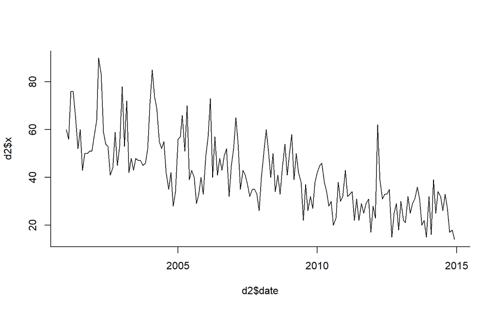

```r
 plot(d2$date,d2$x,  #names of variable
      type='l', #'l' for line plot
      bty='l' #turn off the top and right border
      )
```

### Create some age groups and stratify the data

0 if <2 mo 1 if 2-11 mo 2 if 12-23 mo 3 if 24-59 mo

Create the variable:

```r
d1$agec <- NA
d1$agec[d1$age.years>=0 & d1$age.years<2/12] <-0
d1$agec[d1$age.years>=2/12 & d1$age.years<1] <-1
d1$agec[d1$age.years>=1 & d1$age.years<2] <-2
d1$agec[d1$age.years>=2 & d1$age.years<5] <-3

age.labels<-c('<2m','2-11m','12-23m','24-59m')
```

```r
d3<-aggregate(d1$j12_j18, by=list('agec'=d1$agec,'date'=d1$date), FUN=sum)

d3<-d3[order(d3$agec, d3$date), ] #sort the rows of the data frame by age and date
names(d3)<-c('agec','date','J12_18')
```

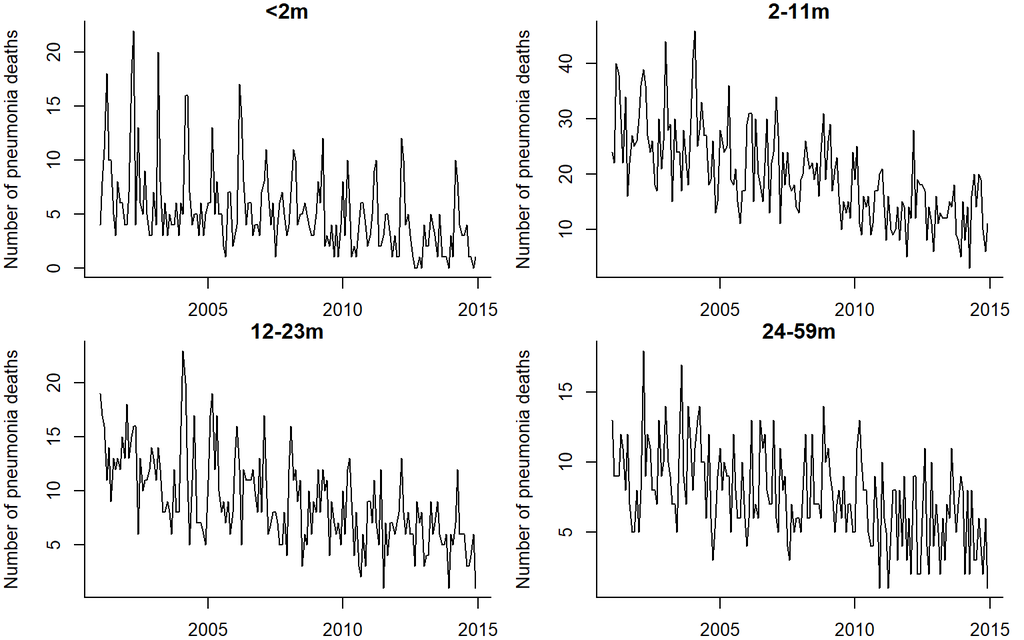

```r
d3.spl<-split(d3,d3$agec) #break up dataframe into 4 pieces; 1 for each age group

par(mfrow=c(2,2), mar=c(2,4,1,1)) #make a plot with arrangement of 2 rows and 2 columns

for(i in 1:length(d3.spl)){
   x<-d3.spl[[i]]
    plot(x$date, x$J12_18, #x-y plot
       bty='l', #turn off right and top border of plot
       type='l', #line plot
       ylab='Number of pneumonia deaths', #label y axis
       xlab='Date', #label x axis
       main=age.labels[i] #add title
       )
}
```

### Extract some control variables

1. Flag any records that has a potential pneumococcal-related code anywhere in the record

```r
# possible_pneumo_code: any pneumo code anywhere
d1$possible_pneumo_code <- 0
d1$possible_pneumo_code[d1$cause %in% c("A40","A49","B953","R652","H10","H65",                                                                   "H66","G00","G01","G02","G03","G04")] <-1
```

A00-B99 primary cause of death:

```r
d1$A00_B99_prim <- ifelse(c(substr(d1$cause, 1, 1) %in% c("A","B")), 1, 0)
d1$A00_B99_prim <- ifelse(c(substr(d1$cause, 1, 2) =="A0" | # Exclude A00-A09 (rotavax)
                              d1$possible_pneumo_code==1), 0, d1$A00_B99_prim)
```

Check your work:

```r
table(d1$A00_B99_prim, d1$possible_pneumo_code) # Good.
```

```
##
##         0     1
##   0 66634   748
##   1  1671     0
```

Also extract some more specific sub-chapter codes

```r
table(d1$cause[substr(d1$cause, 1, 2)=="A1"])
```

```
##
## A15 A16 A17 A18 A19
##   1  43  12   2   6
```

```r
d1$A15_A19_prim <- ifelse(c(substr(d1$cause, 1, 2) =="A1"), 1, 0)
d1$A15_A19_prim <- ifelse(d1$possible_pneumo_code==1, 0, d1$A15_A19_prim)
table(d1$cause[substr(d1$cause, 1, 2)=="A1"], d1$possible_pneumo_code[substr(d1$cause, 1, 2)=="A1"])
```

```
##
##        0
##   A15  1
##   A16 43
##   A17 12
##   A18  2
##   A19  6
```

Check your work

```r
table(d1$A15_A19_prim, d1$possible_pneumo_code)
```

```
##
##         0     1
##   0 68241   748
##   1    64     0
```

And let’s add in a few more controls

```r
d1$p_prim<- 1*(substr(d1$cause,1,1)=='P') #logical test for whether code starts with P
d1$p_prim[d1$possible_pneumo_code==1]<-0 #don't count of pneumococcal code is present

d1$q_prim<- 1*(substr(d1$cause,1,1)=='Q') #logical test for whether code starts with P
d1$q_prim[d1$possible_pneumo_code==1]<-0 #don't count of pneumococcal code is present

d1$w_prim<- 1*(substr(d1$cause,1,1)=='W') #logical test for whether code starts with w
d1$w_prim[d1$possible_pneumo_code==1]<-0 #don't count of pneumococcal code is present

d1$g_prim<- 1*(substr(d1$cause,1,1)=='G') #logical test for whether code starts with P
d1$g_prim[d1$possible_pneumo_code==1]<-0 #don't count of pneumococcal code is present
```

## Now aggregate the outcome and the controls

```r
d2<-aggregate(d1[ ,c('j12_j18','A15_A19_prim','A00_B99_prim','p_prim','q_prim','w_prim','g_prim')], by=list('agec'=d1$agec, 'date'=d1$date), FUN=sum)
str(d2)
```

```
## 'data.frame':    672 obs. of  9 variables:
##  $ agec        : num  0 1 2 3 0 1 2 3 0 1 ...
##  $ date        : Date, format: "2001-01-01" "2001-01-01" ...
##  $ j12_j18     : num  4 24 19 13 8 22 17 9 11 40 ...
##  $ A15_A19_prim: num  0 0 0 2 0 0 0 0 0 1 ...
##  $ A00_B99_prim: num  4 9 6 5 4 16 3 6 5 10 ...
##  $ p_prim      : num  246 5 0 0 168 6 0 0 204 8 ...
##  $ q_prim      : num  23 22 2 2 16 17 1 2 25 14 ...
##  $ w_prim      : num  1 2 3 9 1 5 3 6 2 3 ...
##  $ g_prim      : num  1 2 1 4 0 4 2 2 2 2 ...
```

## Set up for analysis

###Troubleshooting notes If the analyses here are not working or giving an error, 90% of the time it is because either your date variable is not in the correct format or because the data are not correctly sorted. Use as.Date() to tell R that the date variable is a date. Check the variable types using str(ds) And the data should be sorted by stratum (e.g., age group) and then by date.

###Load the data We are going to switch and start using a pre-formatted time series from Ecuador that has a larger number of control variables and has been more extensively cleaned. It was created using similar steps to the ones used above.

Let’s load the data, which are included with the InterventionEvaluatR package

```r
    data(ecuador_mortality, package = "InterventionEvaluatR") #load the data
    head(ecuador_mortality[,1:5]) #View first few rows and columns
```

```
##        age_group  monthdate J12_J18_prim acm_noj_prim A00_B99_prim
## 11776 ec 2-23m A 2005-01-01           39          146            4
## 11777 ec 2-23m A 2005-02-01           43          128            4
## 11778 ec 2-23m A 2005-03-01           43          115            7
## 11779 ec 2-23m A 2005-04-01           37          138            4
## 11780 ec 2-23m A 2005-05-01           53          159            6
## 11781 ec 2-23m A 2005-06-01           29          128            9
```

```r
    ds<-ecuador_mortality
```

Ensure your date variable is in an R date format. If your variable is in a character or factor format, you need to tell R the format. – %m is a 2 digit month; %b is a month abbreviation (ie Jan, Feb) – %d is a 2 digit day (0-31), – %Y is a 4 digit year (e.g. 2011), %y is a 2 digit year (e.g. 11).  
These codes are separated by a dash or slash or space. Modify the tryFormats script below if needed to match the format in your dataset

```r
ds$monthdate<-as.Date(ds$monthdate, tryFormats=c('%Y-%m-%d',
                                                    '%m-%d-%Y',
                                                    '%m/%d/%Y',
                                                    '%Y/%m/%d',
                                                    '%d/%m/%Y'
                                                    ) )
```

Check the variable types

```r
str(ds)
```

```
## 'data.frame':    432 obs. of  198 variables:
##  $ age_group   : Factor w/ 3 levels "ec 2-23m A","ec 2-59m A",..: 1 1 1 1 1 1 1 1 1 1 ...
##  $ monthdate   : Date, format: "2005-01-01" "2005-02-01" ...
##  $ J12_J18_prim: int  39 43 43 37 53 29 26 30 22 20 ...
##  $ acm_noj_prim: int  146 128 115 138 159 128 110 122 100 113 ...
##  $ A00_B99_prim: int  4 4 7 4 6 9 3 3 5 2 ...
##  $ A00_A09_prim: int  24 14 12 23 21 16 30 18 14 9 ...
##  $ A15_A19_prim: int  0 0 1 2 0 0 0 1 0 0 ...
##  $ A20_A28_prim: int  0 0 0 0 0 0 0 0 0 0 ...
##  $ A30_49_prim : int  4 1 3 0 4 7 1 1 3 1 ...
##  $ A50_A64_prim: int  0 0 0 0 0 0 0 0 0 1 ...
##  $ A65_A69_prim: int  0 0 0 0 0 0 0 0 0 0 ...
##  $ A70_A74_prim: int  0 0 0 0 0 0 0 0 0 0 ...
##  $ A75_A79_prim: int  0 0 0 0 0 0 0 0 0 0 ...
##  $ A80_A89_prim: int  0 0 0 0 0 0 0 0 0 0 ...
```

[output cut: 86 more lines]

### Set parameters for analysis

Here we need to set a few parameters. We use the evaluatr.init() function to specify the name of the dataset, the date at which the vaccine is introduced, the date at which we want to begin evaluating the vaccine (typically 1-2 year after vaccine introduction). We also provide some information on the dataset, sch as whether the data are monthly or quarterly (n_seasons), the variable names for the grouping variable, the date variable, the outcome variable, and the denominator variable (if any). You can also set the number of interations for the MCMC. the default is to use a burn-in period of 5000 iterations and to sample 10,000 iterations afterthe burn in. This is a decent place to start. After evaluating model convergence (see below), you might want to increase the burn-in period.

```r
analysis <- evaluatr.init(
  country = "Ecuador", data = ds,
  post_period_start = "2010-08-01", #First 'post-intervention' month is August 2010
  eval_period_start = "2011-08-01", #We ignore first 12 month of data to allow for vaccine ramp up
  eval_period_end = "2015-12-01", #The evaluation period lasts 4 years
  n_seasons = 12, #This is monthly data, so select 12
  year_def = "cal_year", # we are in southern hemisphere, so aggregate results by calendar year (Jan-Dec)
  group_name = "age_group",  #Strata categry name
  date_name = "monthdate", #Date variable name
  outcome_name = "J12_J18_prim", #Outcome variable name
  denom_name = "acm_noj_prim" , #Denominator variable name
  log.covars=TRUE, #log-transform the covariates
  set.burnN=5000,
  set.sampleN=10000
)
set.seed(1)
```

### Sort data by age group and month

```r
    ds<-ds[order(ds[, analysis$group_name], ds[,analysis$date_name]),] #Sort data by age group and month
```

## Run analyses

This function runs Interrupted time series analysis, an alternative time trend analysis, synthetic controls, and STL+PCA. All of these results are saved in the object ‘impact_results’.

### Run a simple control analysis, controlling for 1 control variable at a time

Before getting into more complicated analyses, we will first try to fit a simple Poisson regression model (with overdispersion) where we adjust for seasonality and 1 control variable at a time. These models are fit to data from the pre-vaccine periods and extrapolated to the post-vaccine period. Fitting 1 control variable at a time allows us to see how the use of different controls influences the results. This take a few minutes, so we will use a pre-run set of results.

```r
 glmer_results= evaluatr.univariate(analysis)
```

Then plot the results. The results are ordered by goodness of fit (based on AIC scores), with best fitting covariates on top. Each plot represents a different age group. Overall, we see a generally consistent pattern. The use of the subchapter R00-09 as a control variable leads to estimates that are closer to 1 (no effect). This subchapter is “Symptoms and signs involving the circulatory and respiratory systems”. These are often considered non-specific ‘junk’ codes. There could be arguments for or against using this subchapter as a control. On the downside, it is possible that actual pneumonia deaths incorrectly were assigned a code of R00-99, and the vaccine could therefore reduce the incidence of R00-09 codes and bias the estimates towards no effect. On the upside, the use of these junk codes as a control could help to adjust for underlying improvements or changes in coding quality.

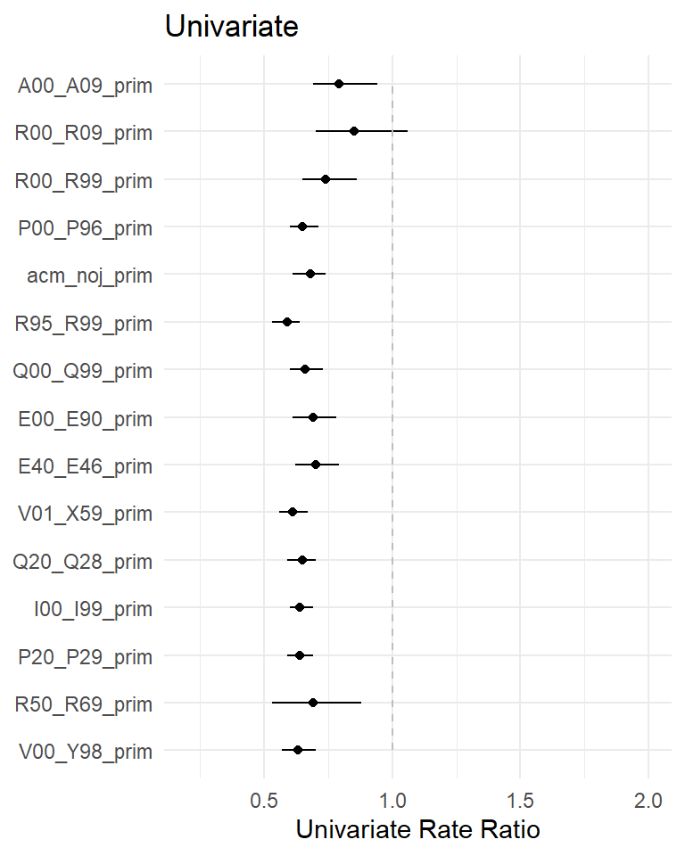

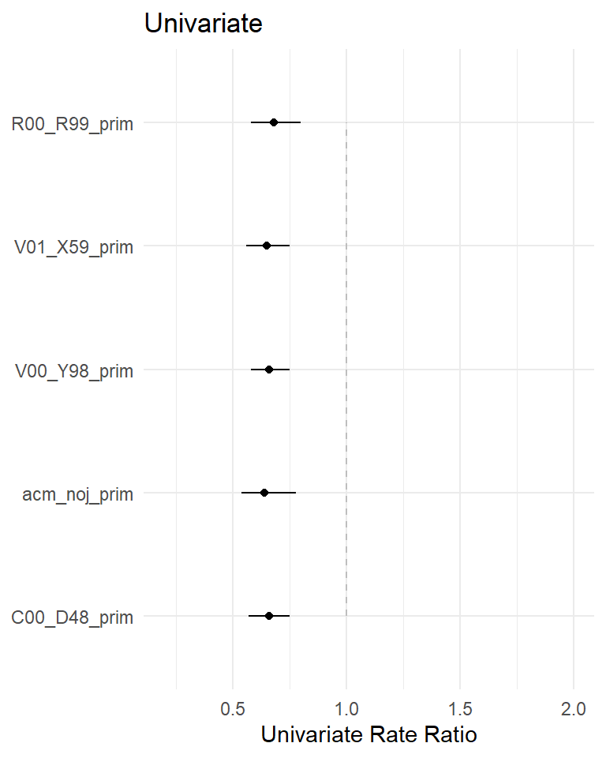

```r
par(mar=c(4,5,1,1)) #fix margins
group.labels<-as.character(unique(analysis$input_data[,analysis$group_name]))
lapply(glmer_results,evaluatr.univariate.plot)
```

### Run Synthetic control analysis

For teaching purposes, this code has been pre-run since it takes some time and computational resources.

```r
impact_results = evaluatr.impact(analysis)
saveRDS(impact_results,'./Results/ec_sc.rds')
```

## Compare estimates from different models

This shows the estimated rate ratio and 95% credible intervals from a synthetic controls analysis; a time-trend analysis where we used the specified denominator (all non-respiratory deaths) to adjust the number of pneumonia deaths in each month and a linear trend for time; a classic interrupted time series analysis (segmented regression); and the STL+PCA approach, which smooths and combines the control variables prior to including them in the model.

```r
results.table<- cbind.data.frame(
  impact_results$full$rr_mean_intervals,
  impact_results$time$rr_mean_intervals,
  impact_results$its$rr_mean_intervals,
  impact_results$pca$rr_mean_intervals)

  table<-xtable(results.table)

  htmlTable(table)
```

|  | Synthetic controls Estimate (95% CI) | Time trend Estimate (95% CI) | Classic ITS (95% CI) | STL+PCA Estimate (95% CI) |
| --- | --- | --- | --- | --- |
| ec 2-23m A | 0.8 (0.62, 1.06) | 0.83 (0.66, 1.06) | 0.93 (0.75, 1.14) | 1.05 (0.81, 1.35) |
| ec 24-59m A | 0.67 (0.58, 0.78) | 0.84 (0.57, 1.24) | 0.71 (0.49, 1.02) | 0.73 (0.39, 1.36) |

## Cases averted

How many cases were prevented from the time of vaccine introduction to the last time point in each stratum (+/- 95% CrI)? You can modify the number ‘last.point’ to pull out the cumulative number of cases at any point in the time series. In this case we are printing results fromthe SC model

```r
last.point<-dim(impact_results$full$cumsum_prevented)[1]
cum.prevented<-impact_results$full$cumsum_prevented[last.point,,]
```

Format and print table

```r
cum1<- round(t(cum.prevented))
cum2<- paste0(cum1[,'50%'], ' (', cum1[,'2.5%'],', ',cum1[,'97.5%'],')')
cum3<-cbind.data.frame(row.names(cum1), cum2)
names(cum3)<-c('Stratum','Cases Averted (95% CrI)')
  htmlTable(cum3, align='l')
```

|  | Stratum | Cases Averted (95% CrI) |
| --- | --- | --- |
| 1 | ec 2-23m A | 309 (-20, 718) |
| 2 | ec 24-59m A | 162 (96, 235) |

## Number of variables selected in SC analysis

```r
model_size = data.frame(t(analysis$model_size))
htmlTable(model_size, align='c')
```

|  | ec.2.23m.A | ec.24.59m.A |
| --- | --- | --- |
| 1 | 2.05 | 0.43 |

## Inclusion Probabilities

```r
incl_probs <- NULL
for (group in analysis$groups) {
  incl_prob <- impact_results$full$groups[[group]]$inclusion_probs[-c(1:(analysis$n_seasons - 1)), ]
  incl_prob <- incl_prob[order(-incl_prob$inclusion_probs), ]
  incl_prob <- incl_prob[c(1:3), ]
  incl_prob2 <- round(incl_prob[, 2],2)
  incl_prob_names <- incl_prob[, 1]
  incl_prob3 <- data.frame("Group" = group, "Greatest Inclusion Variable" = incl_prob_names[1], "Greatest Inclusion Probability" = incl_prob2[1], "Second Greatest Inclusion Variable" = incl_prob_names[2], "Second Greatest Inclusion Probability" = incl_prob2[2], "Third Greatest Inclusion Variable" = incl_prob_names[3], "Third Greatest Inclusion Probability" = incl_prob2[3], check.names = FALSE)
  incl_probs <- rbind(incl_probs, incl_prob3)
}
rownames(incl_probs) <- NULL
```

Here we can see which variables received the most weight in the models for each strata. Values range from 0-1, with values closer to 1 indicating that the variable was included in a larger proportion of the variable combinations that were tested A value of 1 would indicate that the variable was always included in the model, a value of 0.48 would indicate the variable was included in 48% of the models that were tested.

```r
htmlTable(incl_probs)
```

|  | Group | Greatest Inclusion Variable | Greatest Inclusion Probability | Second Greatest Inclusion Variable | Second Greatest Inclusion Probability | Third Greatest Inclusion Variable | Third Greatest Inclusion Probability |
| --- | --- | --- | --- | --- | --- | --- | --- |
| 1 | ec 2-23m A | P00_P96_prim | 0.52 | R00_R09_prim | 0.34 | A00_A09_prim | 0.33 |
| 2 | ec 24-59m A | acm_noj_prim | 0.1 | R00_R99_prim | 0.1 | V01_X59_prim | 0.09 |

###Sensitivity analysis In the sensitivity analyses, we re-run the synthetic controls analysis, but sequentially drop the top 1,2, or 3 variables that were most influential (received the most weight) in the original analysis. This allows us to evaluate whether the results are sensitive to the inclusion of a specific variable

Load the pre-run results

The purpose of this analysis is to evaluate the sensitivity of the synthetic controls results to the inclusion of specific control variables. The model is first fit with all variables, then the top-weighted variable is excluded, and the model is re-run. If the results change drastically after dropping 1 variable, this indicates that that variable is highly influential on the results. If the results don’t change, this indicates that the results are robust to the exclusion of that variable (this assumes that the variable that is excluded received a decent amount of weight prior to exclusion)

```r
if (exists("sensitivity_results")) {
  htmlTable(sensitivity_results$sensitivity_table_intervals)
}
```

|  | Estimate (95% CI) | Top Control 1 | Inclusion Probability of Control 1 | Control 1 Estimate (95% CI) | Top Control 2 | Inclusion Probability of Control 2 | Control 2 Estimate (95% CI) | Top Control 3 | Inclusion Probability of Control 3 | Control 3 Estimate (95% CI) |
| --- | --- | --- | --- | --- | --- | --- | --- | --- | --- | --- |
| ec 2-23m A | 0.8 (0.62, 1.06) | P00_P96_prim | 0.52 | 0.8 (0.6, 1.07) | R00_R09_prim | 0.34 | 0.75 (0.59, 0.93) | A00_A09_prim | 0.33 | 0.68 (0.58, 0.85) |
| ec 24-59m A | 0.67 (0.58, 0.78) | acm_noj_prim | 0.1 | 0.67 (0.58, 0.77) | R00_R99_prim | 0.1 | 0.66 (0.58, 0.76) | V01_X59_prim | 0.09 | 0.67 (0.59, 0.77) |

## Generate and save the plots

## Plot the results for 1 age group

### First look at the results from the synthetic controls model for 1 age group.

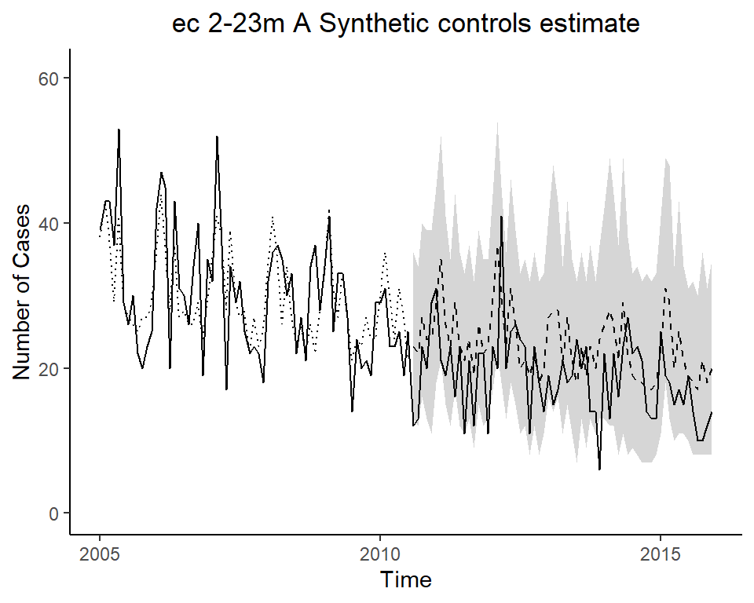

```r
      plots$groups[["ec 2-23m A"]]$pred_full
```

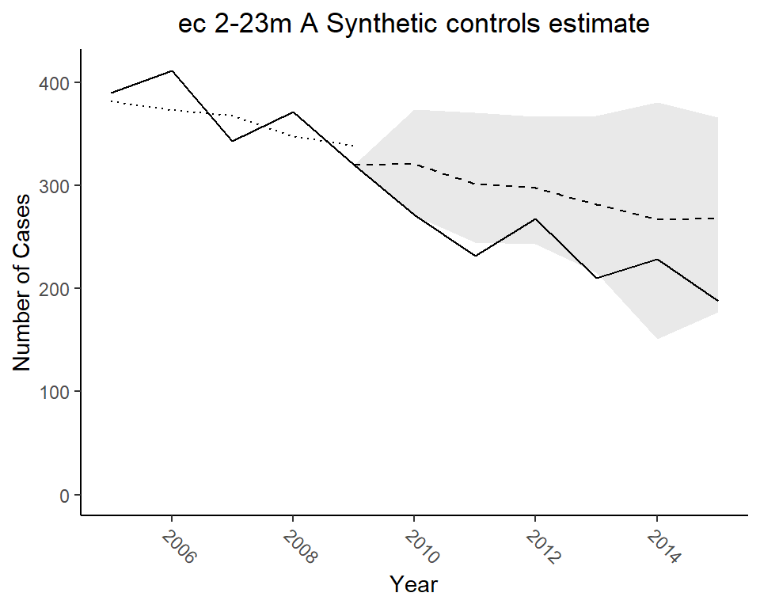

```r
      plots$groups[["ec 2-23m A"]]$pred_full_agg
```

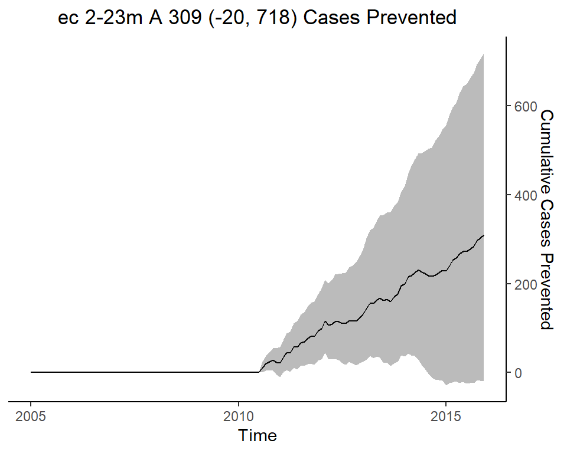

```r
      plots$groups[["ec 2-23m A"]]$cumsum_prevented
```

## Printing plots for all models and age groups

We instead might want to just print everything for all age groups and models. We can use the following code to do that

## Plot Observed vs expected yearly time series

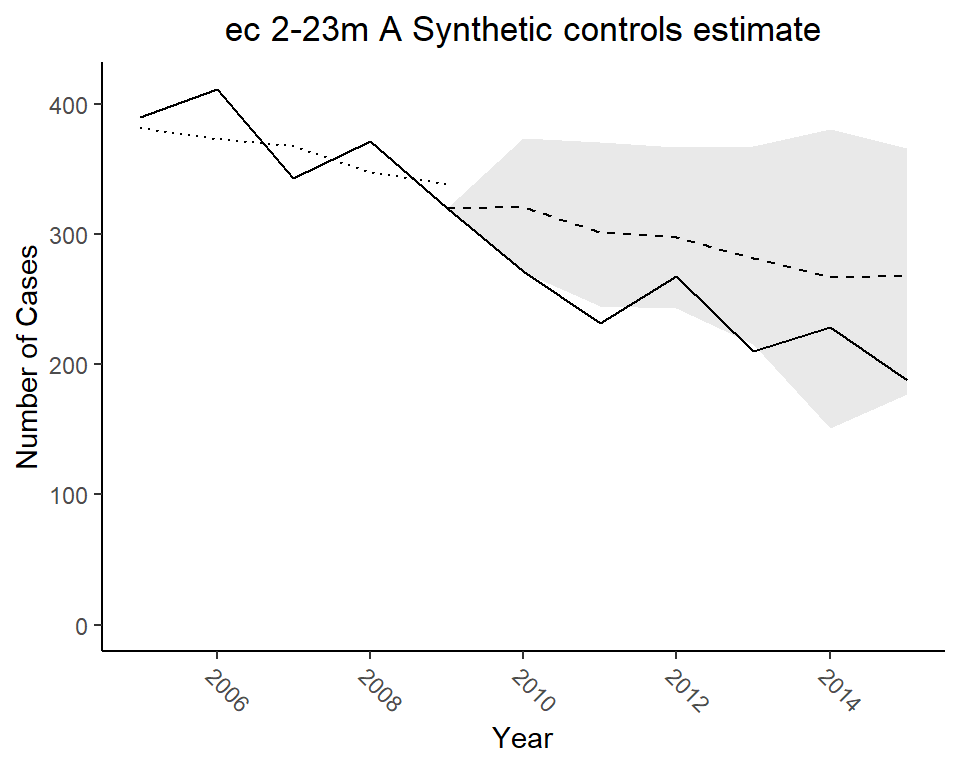

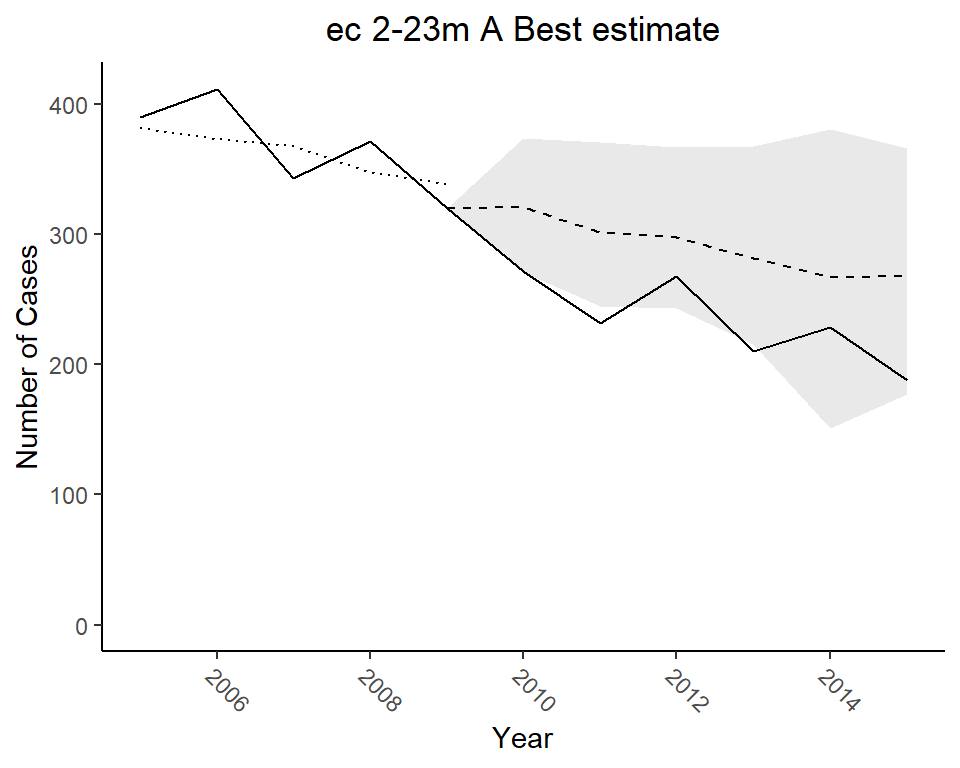

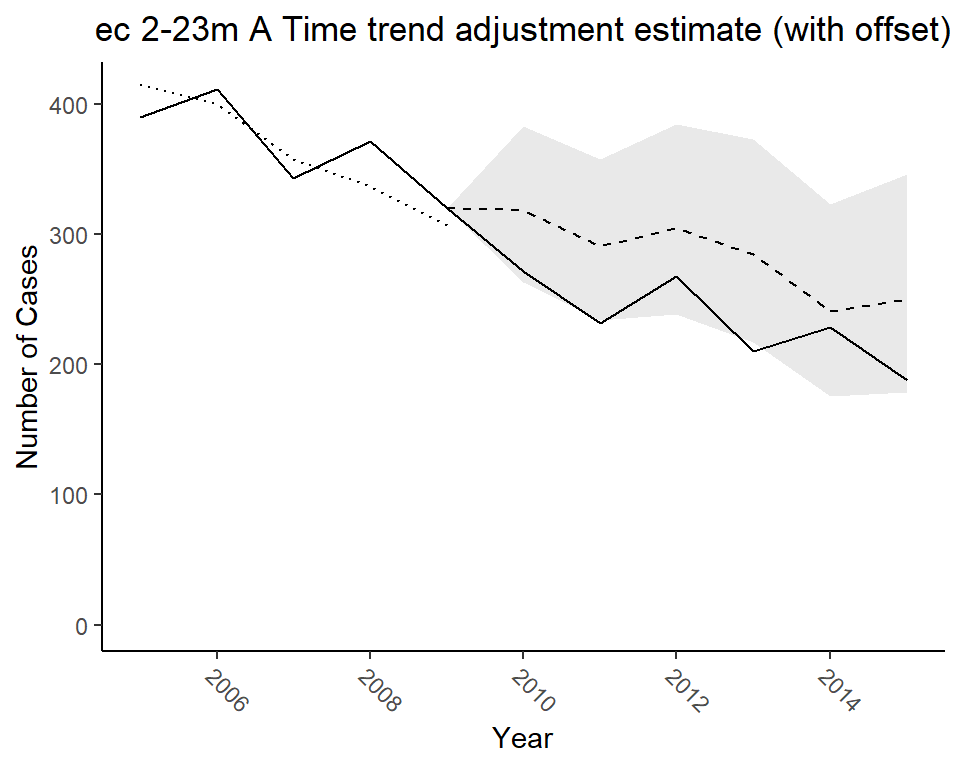

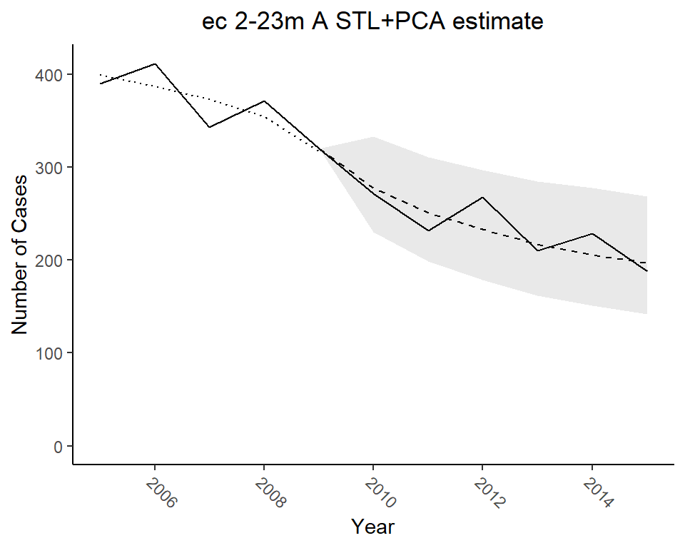

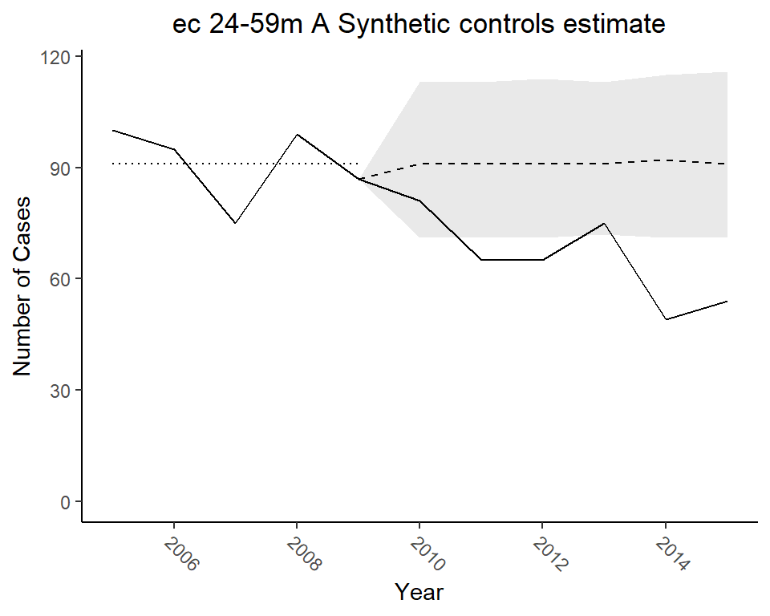

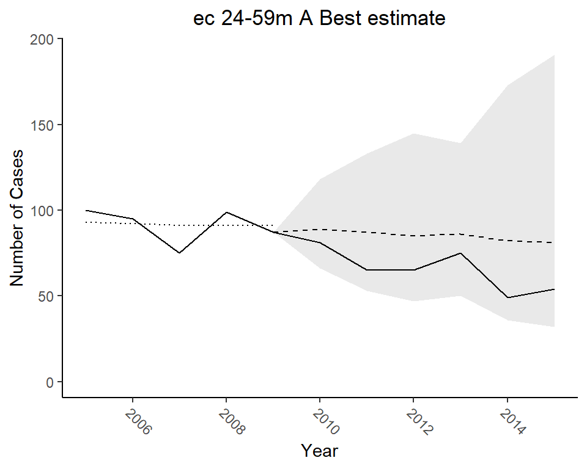

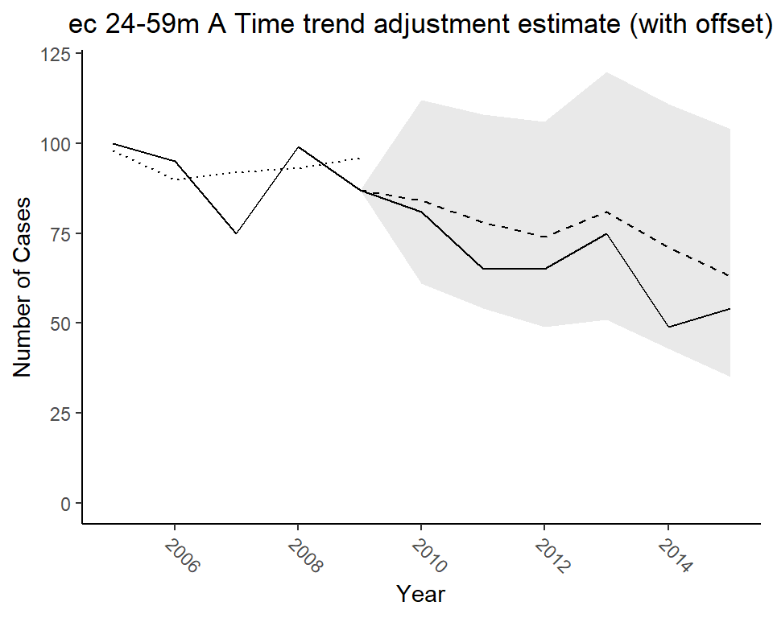

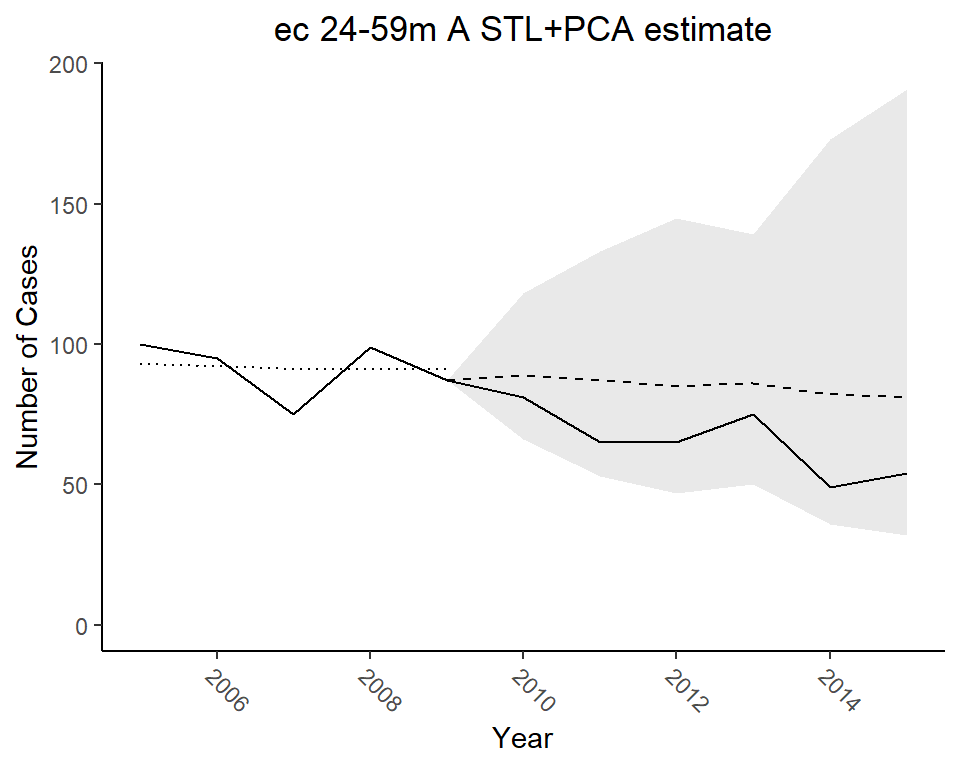

```r
      par(mfrow=c(4,1))

for (group in names(plots$groups)) {
      print(plots$groups[[group]]$pred_full_agg )
      print(plots$groups[[group]]$pred_best_agg )
      print(plots$groups[[group]]$pred_time_agg )
      print(plots$groups[[group]]$pred_pca_agg )
}
```